# COMPSCIX 415.2 Homework 9/Final

Mario Casas Gonzalez

August 9, 2018

```r
library(tidyverse)
library(dplyr)
library(mdsr)
library(broom)
library(readr)
```

Hyperlink to my Github repository: https://github.com/casasgmario/compscix-415-2-assignments.git

## Exercise 1 - Sampling Distributions, Functions and For Loops (10 points)

### Step 1

```r
samp_size <- 100
samp_rate <- 1/10000

samp_fun <- function(samp_size, samp_rate) {
my_samp <- rexp(n = samp_size, rate = samp_rate)
samp_avg <- mean (my_samp)
samp_std_dev <- sd(my_samp)
stats <- list(samp_avg = samp_avg, samp_std_dev = samp_std_dev)
return(stats)
}

samp_fun(samp_size, samp_rate)
```

```
## $samp_avg
## [1] 9899.217
##
## $samp_std_dev
## [1] 10659.01
```

### Step 2

```r
n <- 1000
samp_size <- 50
samp_rate <- 1/10000
sample_means <- c(0)
sample_sds <- c(0)


for (i in 1:n) {
  samp_size <- 50
  samp_rate <- 1/10000
  my_list <- samp_fun(samp_size, samp_rate)
  sample_means[[i]] <- my_list$samp_avg
  sample_sds[[i]] <- my_list$samp_std_dev
}
```

### Step 3

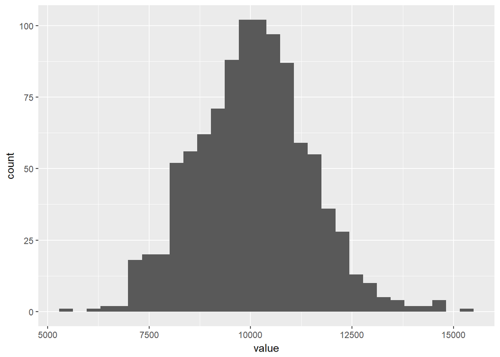

```r
sample_means_df <- as_data_frame(sample_means)
ggplot(sample_means_df, aes(x=value)) + geom_histogram()
```

```r
my_sd <- sd(sample_means)
my_sd
```

```
## [1] 1399.525
```

```r
theor_std_error <- my_sd/sqrt(samp_size)
```

### Step 4

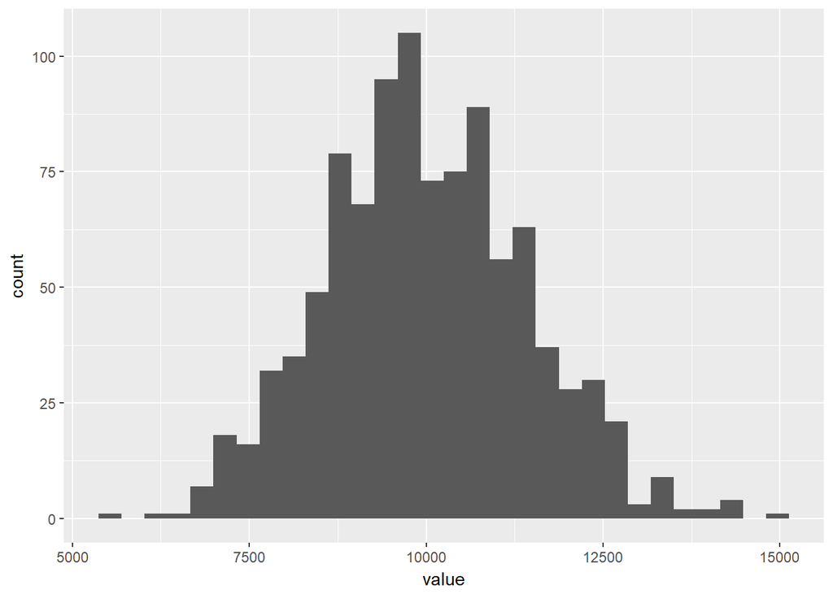

```r
n <- 1000
samp_size <- 500
samp_rate <- 1/10000
sample_means <- c(0)
sample_sds <- c(0)


for (i in 1:n) {
  samp_size <- 50
  samp_rate <- 1/10000
  my_list <- samp_fun(samp_size, samp_rate)
  sample_means[[i]] <- my_list$samp_avg
  sample_sds[[i]] <- my_list$samp_std_dev
}

sample_means_df <- as_data_frame(sample_means)
ggplot(sample_means_df, aes(x=value)) + geom_histogram()
```

```r
my_sd <- sd(sample_means)
my_sd
```

```
## [1] 1422.692
```

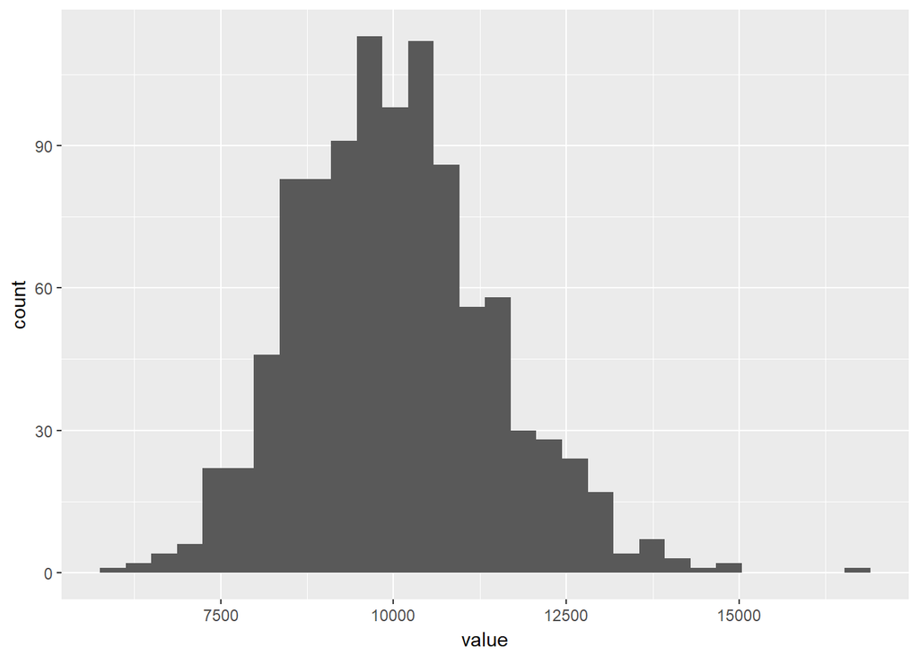

```r
theor_std_error <- my_sd/sqrt(samp_size)

samp_size <- 5000

for (i in 1:n) {
  samp_size <- 50
  samp_rate <- 1/10000
  my_list <- samp_fun(samp_size, samp_rate)
  sample_means[[i]] <- my_list$samp_avg
  sample_sds[[i]] <- my_list$samp_std_dev
}

sample_means_df <- as_data_frame(sample_means)
ggplot(sample_means_df, aes(x=value)) + geom_histogram()
```

```r
my_sd <- sd(sample_means)
my_sd
```

```
## [1] 1418.784
```

```r
theor_std_error <- my_sd/sqrt(samp_size)
```

## Exercise 2 - Linear Regression (5 points)

• Interpret the coefficient on LotArea >> For every increase of 1 sq foot in the LotArea, the prediction of the model for the Sale Price increases by 1.453, when leaving the other 2 variables fixed (Overall Quality and External Quality)

• Interpret the coefficient on ExterQualGd >> For every increase of 1 unit in the ExterQualGd factor, the prediction of the model for the Sale Price decreases by 71529, when leaving the other 2 variables fixed (Lot Area and Overall Quality)

• Compare this model to the model we fit in HW 7 with GrLivArea, OverallQual, Neighborhood. Which is the better fitting model? >> We evaluate this with the adjusted R squared value, which in this case is 0.694 versus 0.783 on the HW 7 model, hence we can infer that the old HW 7 model was a better fit.

```r
train <- read_csv("~/Training/Berkeley/COMPSCI X415.2 - 002 Introduction to Data Science/Homeworks/Final Exam/train.csv")
(my_lm <- lm (SalePrice ~ LotArea + OverallQual + ExterQual, data=train))
```

```
##
## Call:
## lm(formula = SalePrice ~ LotArea + OverallQual + ExterQual, data = train)
##
## Coefficients:
## (Intercept)      LotArea  OverallQual  ExterQualFa  ExterQualGd
##   40763.573        1.453    34466.192   -95352.075   -71529.493
## ExterQualTA
##  -97526.514
```

```r
tidy (my_lm)
```

```
## # A tibble: 6 x 5
##   term         estimate std.error statistic   p.value
##   <chr>           <dbl>     <dbl>     <dbl>     <dbl>
## 1 (Intercept)  40764.   12358.         3.30 9.95e-  4
## 2 LotArea          1.45     0.116     12.5  3.72e- 34
## 3 OverallQual  34466.    1216.        28.3  4.77e-141
## 4 ExterQualFa -95352.   14592.        -6.53 8.80e- 11
## 5 ExterQualGd -71529.    6737.       -10.6  2.05e- 25
## 6 ExterQualTA -97527.    7541.       -12.9  2.72e- 36
```

```r
glance(my_lm)
```

```
## # A tibble: 1 x 11
##   r.squared adj.r.squared  sigma statistic p.value    df  logLik    AIC
## *     <dbl>         <dbl>  <dbl>     <dbl>   <dbl> <int>   <dbl>  <dbl>
## 1     0.695         0.694 43948.      663.       0     6 -17677. 35368.
## # ... with 3 more variables: BIC <dbl>, deviance <dbl>, df.residual <int>
```

## Exercise 3 - AB Testing (5 points)

1. What proportion of visitors converted for each version of the webpage? > 4.15% on Version A and 10% on Version B.
2. Perform the AB test in R. What is the p-value for the AB test (hypothesis test of proportions)? The p-value is 1.25388e-10.

```r
ab_test_data <- read_csv("~/Training/Berkeley/COMPSCI X415.2 - 002 Introduction to Data Science/Homeworks/Final Exam/ab_test_data.csv")
total_conversions <- ab_test_data %>% group_by (version) %>% summarise(total_conversions=sum(conversion))
total_conversions %>% mutate(conversion_rates=total_conversions/2000)
```

```
## # A tibble: 2 x 3
##   version total_conversions conversion_rates
##   <chr>               <int>            <dbl>
## 1 A                      83           0.0415
## 2 B                     200           0.1
```

```r
true_a <- 0.0415
true_b <-0.1
n_a <- 2000
n_b <- 2000
set.seed(10)
samp_a <- rbinom(n = 1, size = n_a, prob = true_a)
samp_b <- rbinom(n = 1, size = n_b, prob = true_b)
two_prop_test <- prop.test(c(samp_a, samp_b), c(2000, 2000))
two_prop_test$p.value
```

```
## [1] 1.25388e-10
```